# Pseudo facebook

Chiara

# Data Analysis with R

## Udacity course

[Click here](https://www.udacity.com/me#!/) for Udacity courses

[GGplot 2 Geoms](http://docs.ggplot2.org/current/)

[Documentation for smooths](http://www.ats.ucla.edu/stat/r/faq/smooths.htm)

Get to the directory and read the file into R (tab separated)

```r
pf = read.csv("C:/Users/cdiloreto/Google Drive/Programming/Data sets and exercises/pseudo_facebook.tsv", sep = "\t")
names(pf)
```

```
##  [1] "userid"                "age"
##  [3] "dob_day"               "dob_year"
##  [5] "dob_month"             "gender"
##  [7] "tenure"                "friend_count"
##  [9] "friendships_initiated" "likes"
## [11] "likes_received"        "mobile_likes"
## [13] "mobile_likes_received" "www_likes"
## [15] "www_likes_received"
```

Load ggplot2 and start with a Quick plot `qplot` on the variable `dob_day`

```
## stat_bin: binwidth defaulted to range/30. Use 'binwidth = x' to adjust this.
```

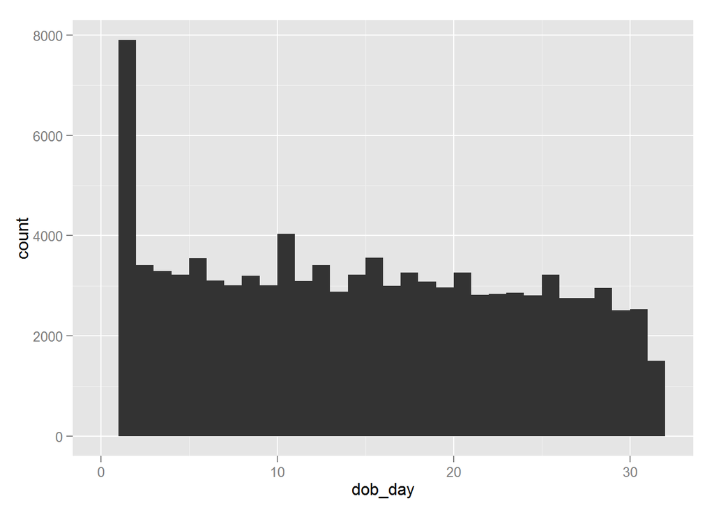

```r
library(ggplot2)
  qplot(x = dob_day, data = pf)
```

### Use discrete position

With `scale_x_discrete`, divide the x axis into 31 values (days of the month)

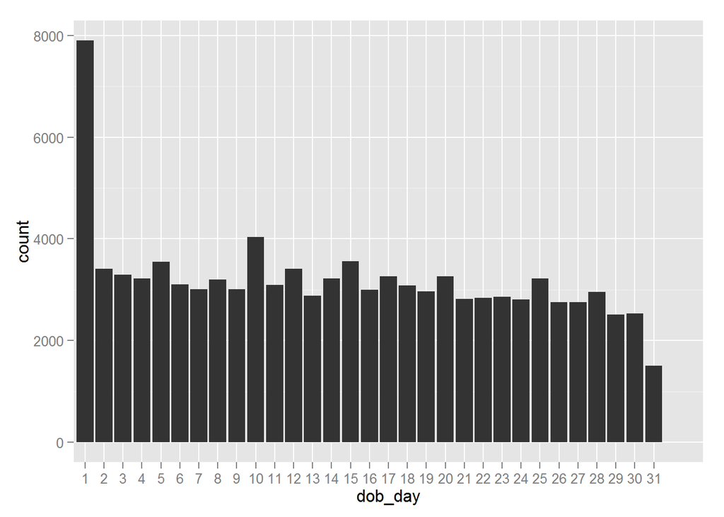

```r
qplot(x = dob_day, data = pf)  +
    scale_x_discrete(breaks = 1:31)
```

Check the help for the Discrete positioning with `?scale_x_discrete` Notice there are different arguments you can pass on to the function. To divide the x axis, we will use `breaks` argument.

### Faceting

Check help with `?facet_wrap`. `facet_wrap` function takes a tilde sign `~` followed by the variable we want to spread our data on.

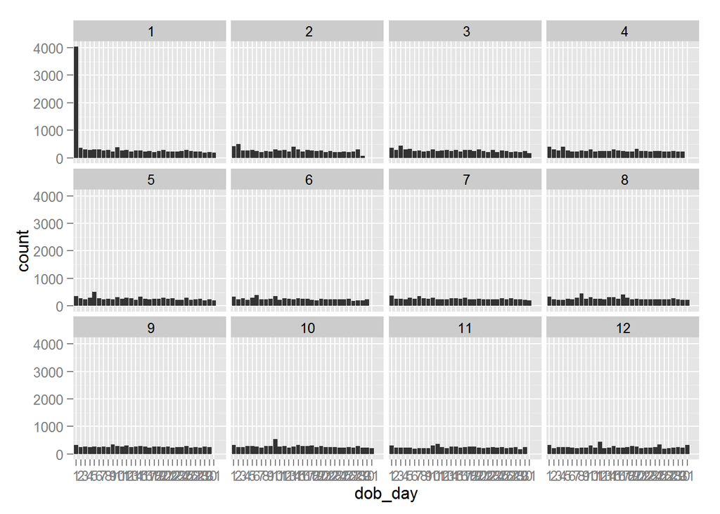

```r
qplot(x = dob_day, data = pf)  +
    scale_x_discrete(breaks = 1:31) +
    facet_wrap(~dob_month)
```

Alternatively, you can set the number of columns like this:

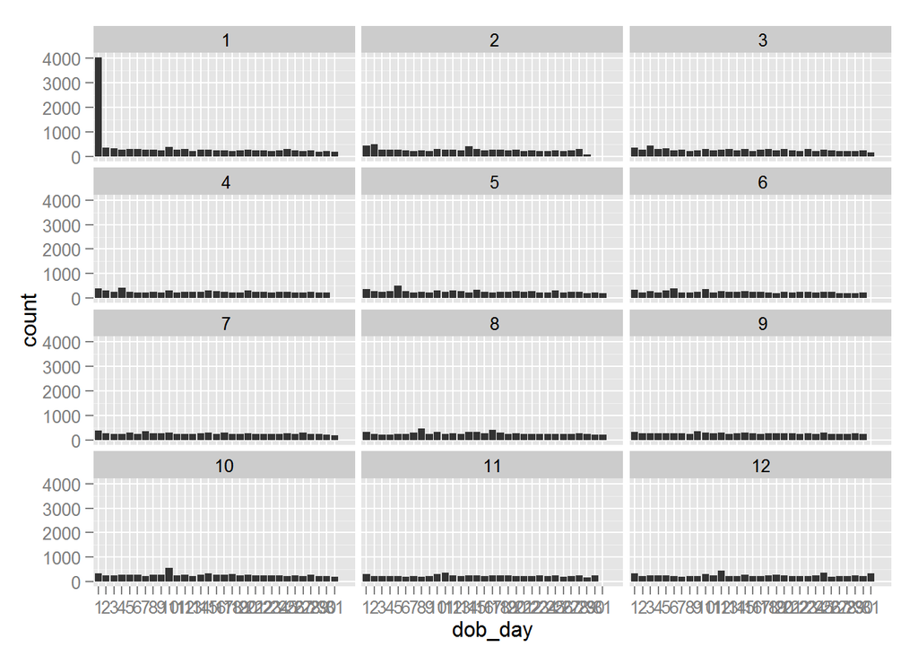

```r
qplot(x = dob_day, data = pf)  +
    scale_x_discrete(breaks = 1:31) +
    facet_wrap(~dob_month, ncol = 3)
```

Now we move on to analyze the `friends_count` variable Quick plot

```
## stat_bin: binwidth defaulted to range/30. Use 'binwidth = x' to adjust this.
## stat_bin: binwidth defaulted to range/30. Use 'binwidth = x' to adjust this.
```

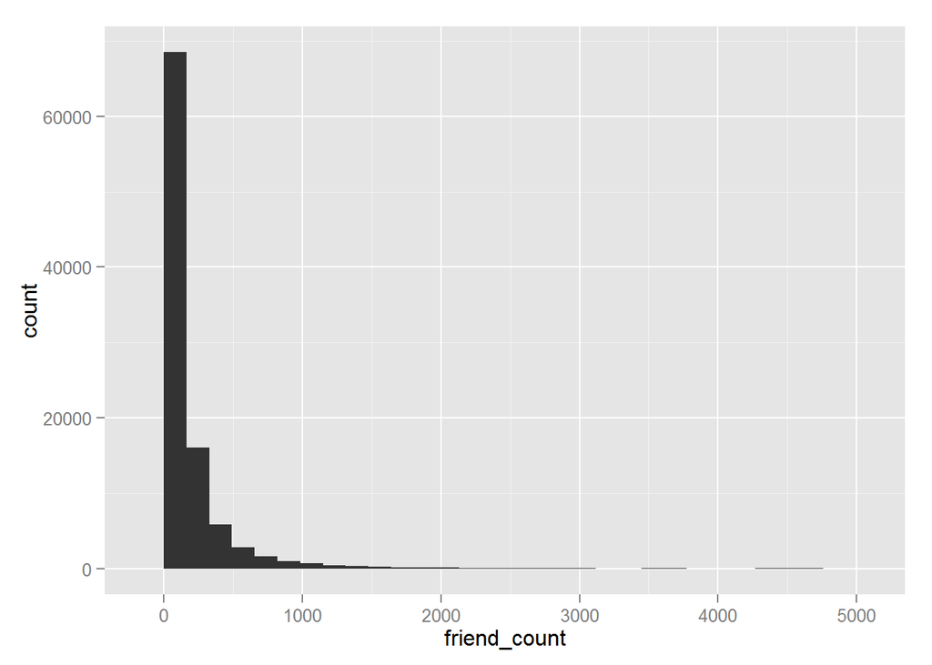

```r
qplot(x = friend_count, data = pf) +
 geom_histogram()
```

Equivalent ggplot

```
## stat_bin: binwidth defaulted to range/30. Use 'binwidth = x' to adjust this.
```

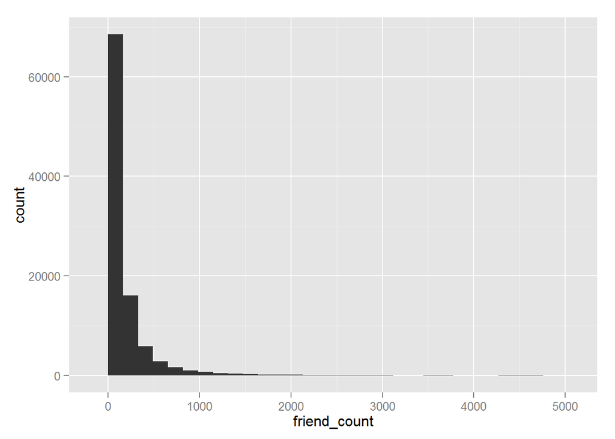

```r
ggplot(aes(x = friend_count), data = pf) +
  geom_histogram()
```

To fix the plot and limit the axis, we can use the `xlim` argument passed to qplot. Alternatively, we can use `scale_x_continuous` function

```
## stat_bin: binwidth defaulted to range/30. Use 'binwidth = x' to adjust this.
```

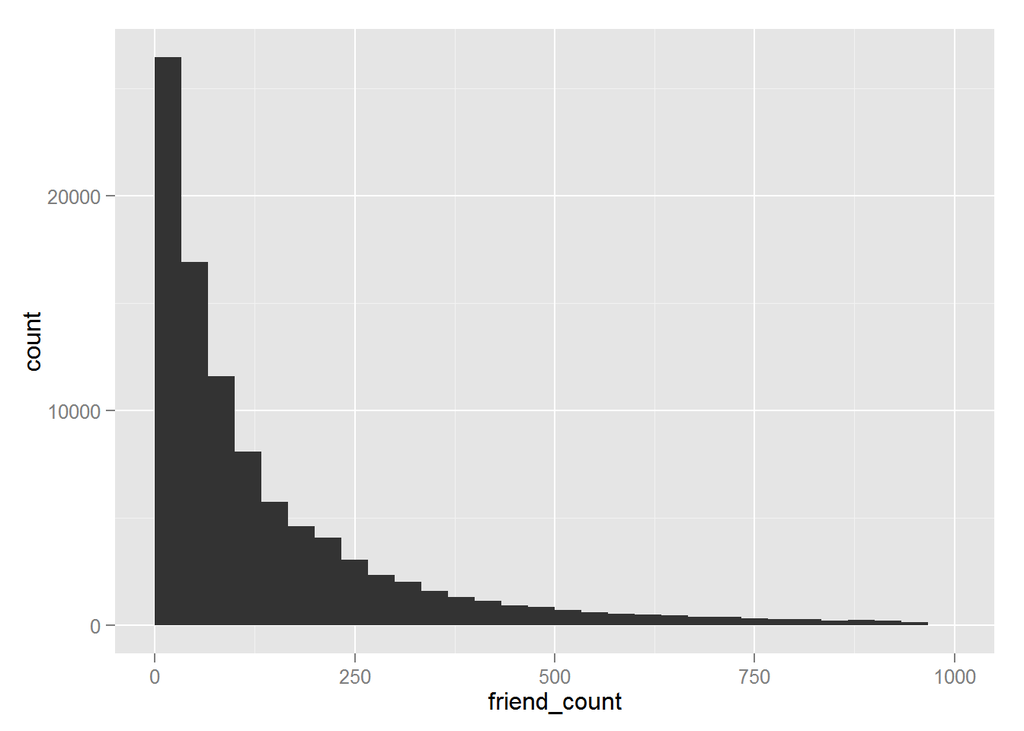

```r
qplot(x = friend_count, data = pf, xlim = c(0, 1000))
```

```
## stat_bin: binwidth defaulted to range/30. Use 'binwidth = x' to adjust this.
```

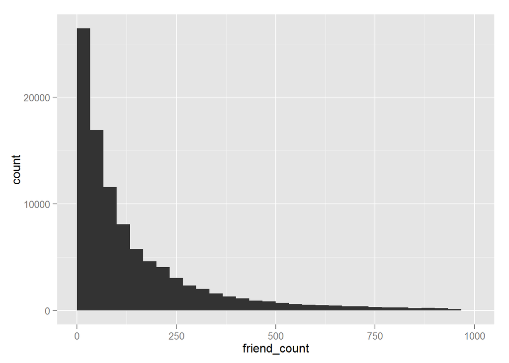

```r
qplot(x = friend_count, data = pf) +
  scale_x_continuous(limits = c(0, 1000))
```

Add a custom binwidth

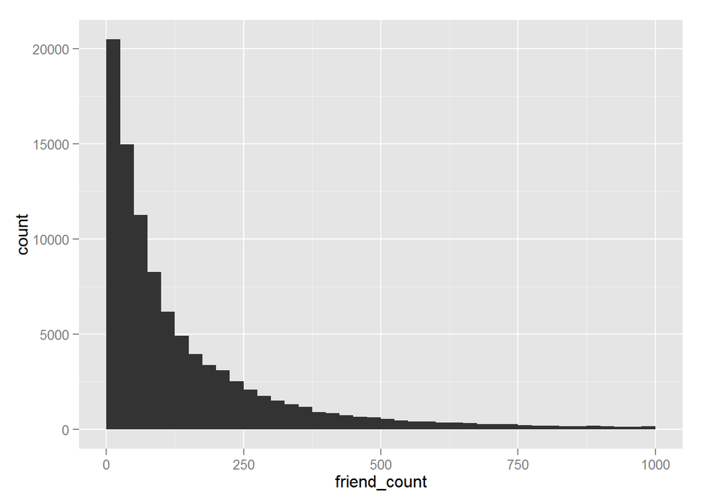

```r
qplot(x = friend_count, data = pf, binwidth = 25) +
    scale_x_continuous(limits = c(0, 1000))
```

Then, add `breaks` on the x axis using `seq()` function

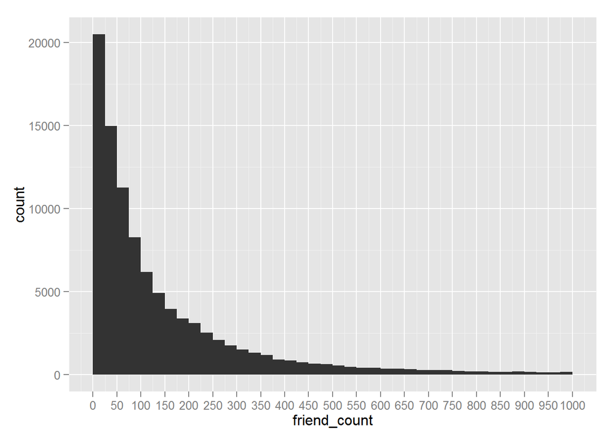

```r
qplot(x = friend_count, data = pf, binwidth = 25) +
    scale_x_continuous(limits = c(0, 1000), breaks = seq(0, 1000, 50))
```

Equivalent ggplot syntax

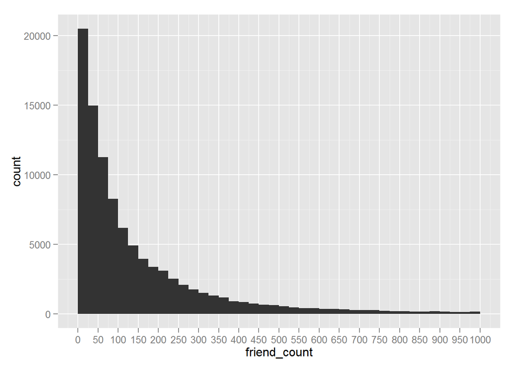

```r
ggplot(aes(x = friend_count), data = pf) +
  geom_histogram(binwidth = 25) +
  scale_x_continuous(limits = c(0, 1000), breaks = seq(0, 1000, 50))
```

To find out which gender, male or female, has more friends on an average, we can use the `facet_wrap` function, like this

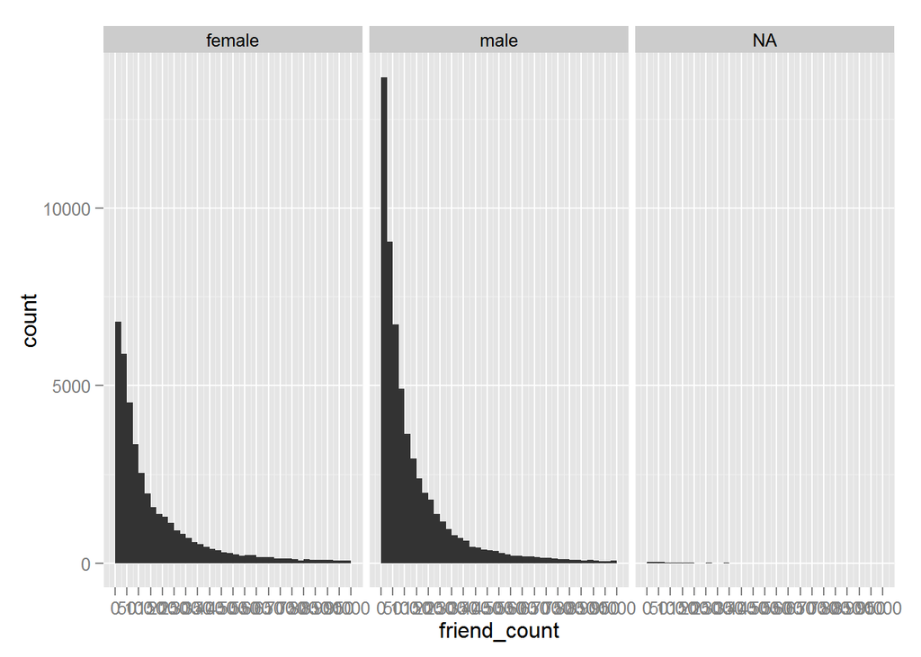

```r
qplot(x = friend_count, data = pf, binwidth = 25) +
      scale_x_continuous(limits = c(0, 1000), breaks = seq(0, 1000, 50)) +
      facet_wrap(~gender)
```

To eliminate the rows that have value `NA` on the gender column, we will use the `is.na()` function with a bank sign `!` before it

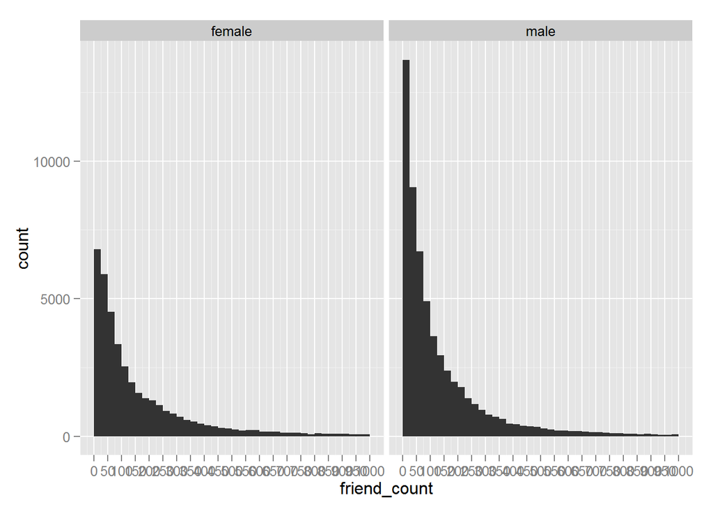

```r
qplot(x = friend_count, data = subset(pf, !is.na(gender)), binwidth = 25) +
      scale_x_continuous(limits = c(0, 1000), breaks = seq(0, 1000, 50)) +
      facet_wrap(~gender)
```

Using the code `data = subset(pf, !is.na(gender))` is better than using `data = na.omit(pf)` because it will only eliminate the rows with NA values on the gender column and not all the rows that have whatsoever NA value in them.

Now we want to check how many males vs. female observations we have in our data set.

```r
table(pf$gender)
```

```
##
## female   male
##  40254  58574
```

Or, include NA’s

```r
table(pf$gender, useNA = "ifany")
```

```
##
## female   male   <NA>
##  40254  58574    175
```

### by() function

By() function uses a dataset `pf$friend_count` and indices it by `pf$gender`, which means the function will return a summary of how many friends per gender.

```r
by(pf$friend_count, pf$gender, summary)
```

```
## pf$gender: female
##    Min. 1st Qu.  Median    Mean 3rd Qu.    Max.
##       0      37      96     242     244    4923
## --------------------------------------------------------
## pf$gender: male
##    Min. 1st Qu.  Median    Mean 3rd Qu.    Max.
##       0      27      74     165     182    4917
```

### Tenure

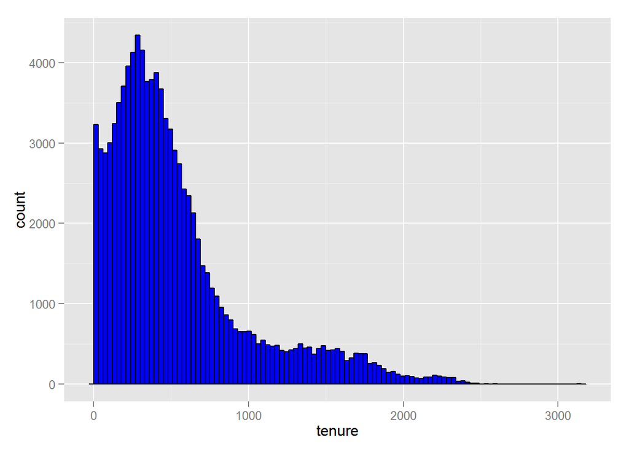

```r
qplot(x = tenure, data = pf, binwidth = 30,
      color = I('black'), fill = I('blue'))
```

##### Analyze tenure by year

Setting breaks and limits helps reading the plot

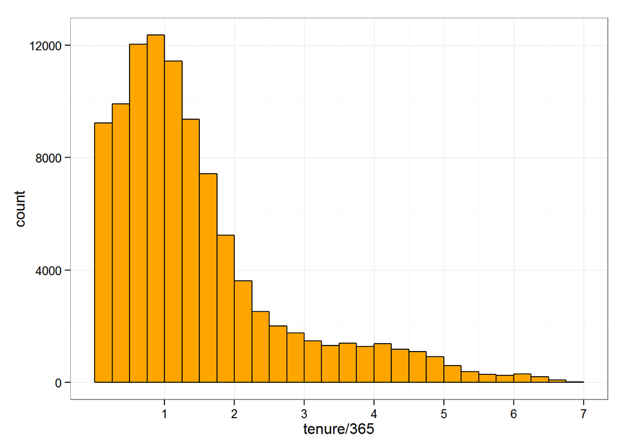

```r
qplot(x = tenure/365, data = pf, binwidth = 0.25,
      color = I('black'), fill = I('orange')) +
  scale_x_continuous(breaks = seq(1, 7, 1), limits = c(0,7)) +
  theme_bw()
```

To add labels to the axis, use ’xlab`and`ylab` arguments passed to the qplot function

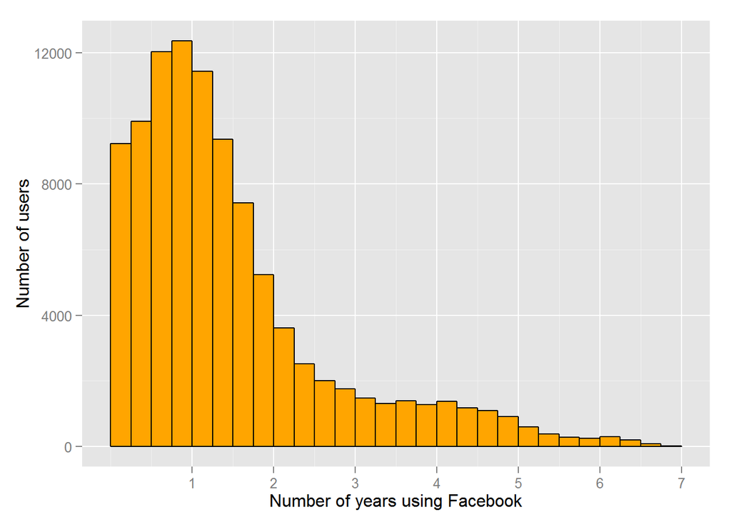

```r
qplot(x = tenure/365, data = pf, binwidth = 0.25,
      xlab = "Number of years using Facebook",
      ylab = "Number of users",
      color = I('black'), fill = I('orange')) +
  scale_x_continuous(breaks = seq(1, 7, 1), limits = c(0,7))
```

### Age

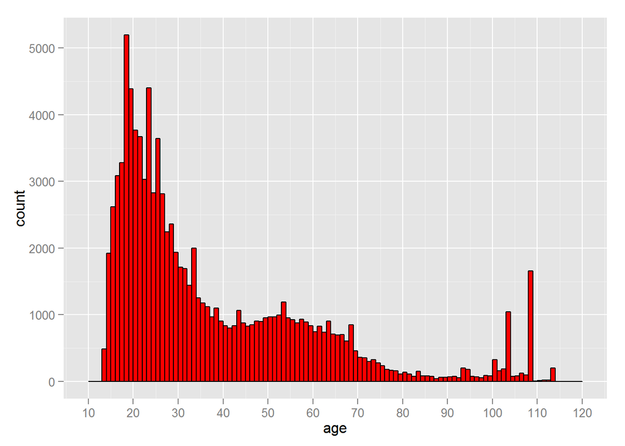

```r
qplot(x = age, data = pf, binwidth = 1,
      color = I('black'), fill = I('red')) +
  scale_x_continuous(breaks = seq(0, 150, 10), limits = c(10, 120))
```

It may help to use the `summary` function on `pf$age` to find out what is the min and max values for age in the dataset.

```r
summary(pf$age)
```

```
##    Min. 1st Qu.  Median    Mean 3rd Qu.    Max.
##   13.00   20.00   28.00   37.28   50.00  113.00
```

### Logarithmic transformation

For overdispersed data, it is useful to use the logarithmic transformation or transform the values with the square root. See why [here](http://www.r-statistics.com/2013/05/log-transformations-for-skewed-and-wide-distributions-from-practical-data-science-with-r/)

Now back to plotting. Create 3 plots in one screen to see the difference. * First create the 3 plots and assign variables to each of them

```r
p1 = qplot(x = friend_count, data = pf)
p2 = qplot(x = log10(friend_count + 1), data = pf)
p3 = qplot(x = sqrt(friend_count), data = pf)
```

- Load gridExtra package

```r
library(gridExtra)
```

- Then put the 3 plots in one single screen

```
## stat_bin: binwidth defaulted to range/30. Use 'binwidth = x' to adjust this.
## stat_bin: binwidth defaulted to range/30. Use 'binwidth = x' to adjust this.
## stat_bin: binwidth defaulted to range/30. Use 'binwidth = x' to adjust this.
```

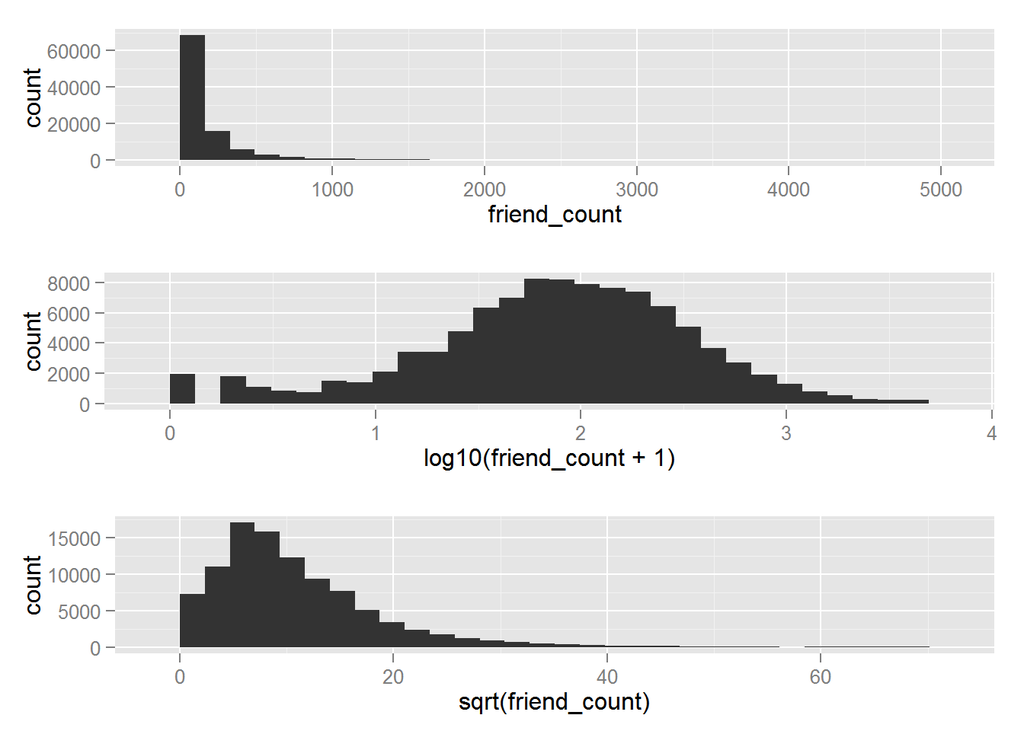

```r
grid.arrange(p1, p2, p3, ncol = 1)
```

### WWW likes

```
## stat_bin: binwidth defaulted to range/30. Use 'binwidth = x' to adjust this.
```

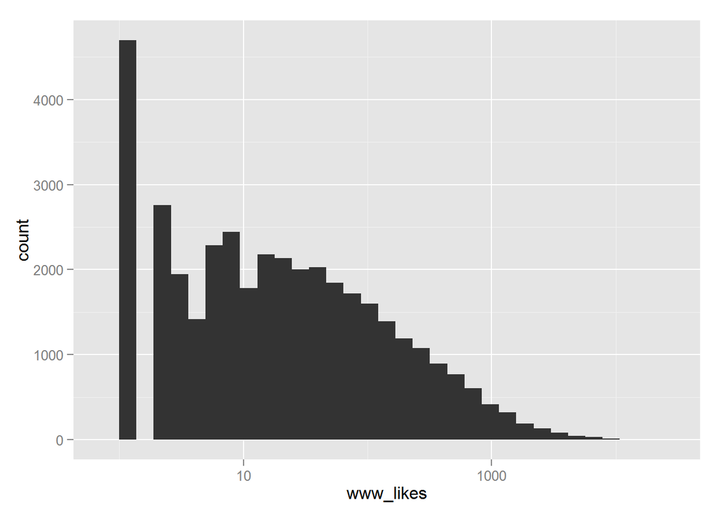

```r
qplot(x = www_likes, data = pf) +
  scale_x_log10()
```

### Analysis per gender and friend count

Frequency poligon for comparing two or more distribution

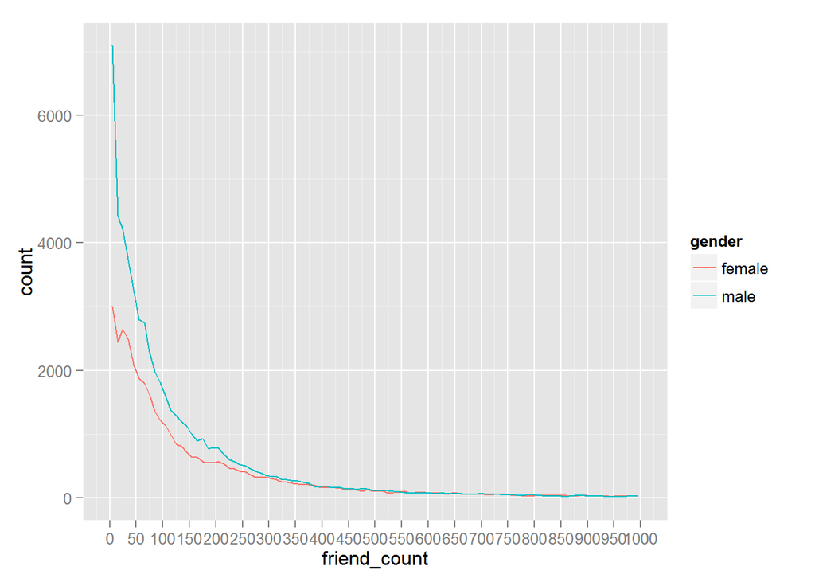

```r
qplot(x = friend_count, data = subset(pf, !is.na(gender)), binwidth = 10, geom = "freqpoly", color = gender) +
      scale_x_continuous(limits = c(0, 1000), breaks = seq(0, 1000, 50))
```

To find out which gender has more friends on average

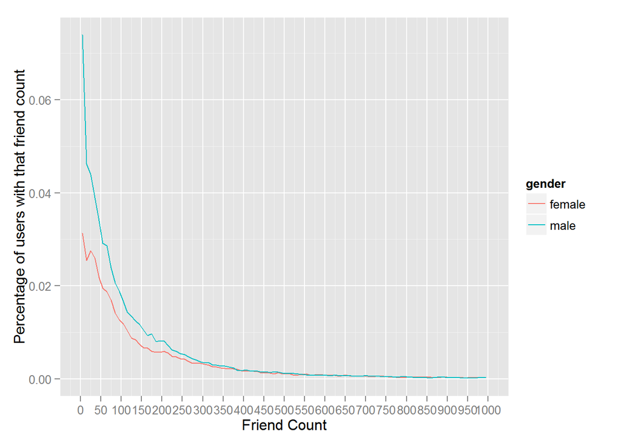

```r
qplot(x = friend_count, y = ..count../sum(..count..),
      data = subset(pf, !is.na(gender)),
      xlab = "Friend Count", ylab = "Percentage of users with that friend count",
      binwidth = 10,
      geom = "freqpoly", color = gender) +
  scale_x_continuous(limits = c(0, 1000), breaks = seq(0, 1000, 50))
```

Equivalent ggplot syntax

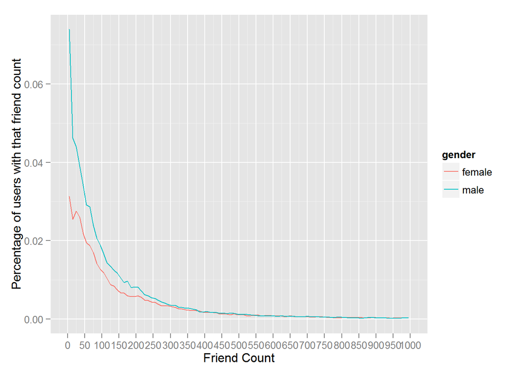

```r
ggplot(aes(x = friend_count, y = ..count../sum(..count..)), data = subset(pf, !is.na(gender))) +
      geom_freqpoly(aes(color = gender), binwidth=10) +
      scale_x_continuous(limits = c(0, 1000), breaks = seq(0, 1000, 50)) +
      xlab('Friend Count') +
      ylab('Percentage of users with that friend count')
```

##### Exercise: Create a frequency poligon to show count of www_likes per gender

```
## stat_bin: binwidth defaulted to range/30. Use 'binwidth = x' to adjust this.
## stat_bin: binwidth defaulted to range/30. Use 'binwidth = x' to adjust this.
```

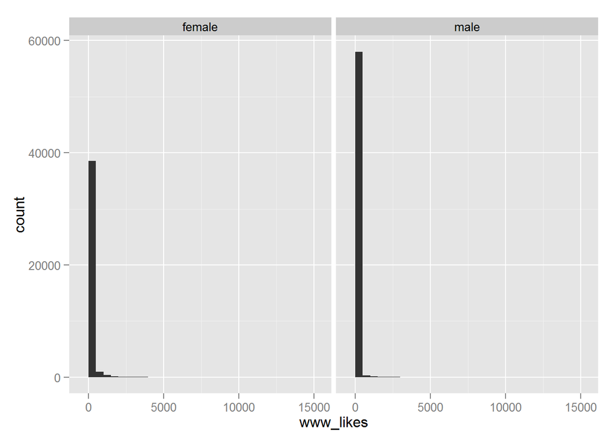

```r
qplot(x = www_likes, data = subset(pf, !is.na(gender))) +
      facet_wrap(~gender)
```

```
## stat_bin: binwidth defaulted to range/30. Use 'binwidth = x' to adjust this.
```

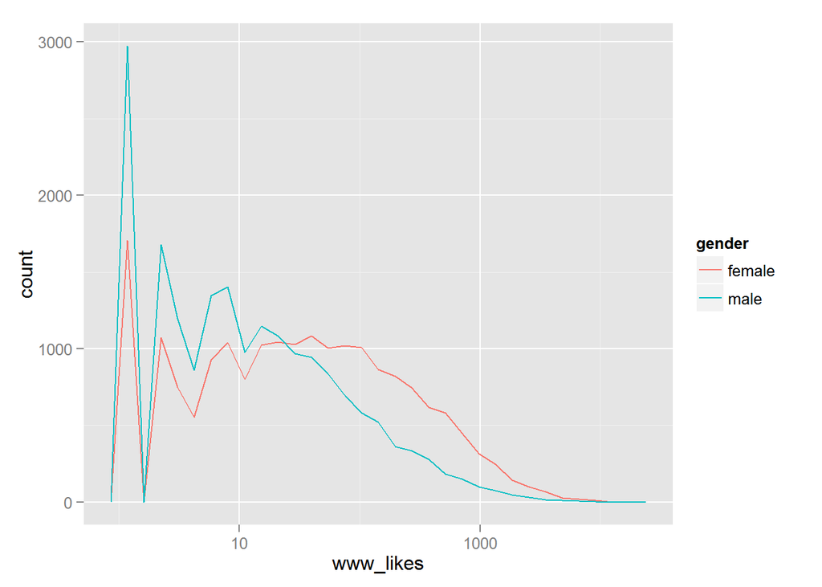

```r
qplot(x = www_likes, data = subset(pf, !is.na(gender)),
      geom = "freqpoly",
      color = gender) +
  scale_x_continuous(limits = c(-1, 10), breaks = seq(0, 10, 1)) +
  scale_x_log10()
```

```
## stat_bin: binwidth defaulted to range/30. Use 'binwidth = x' to adjust this.
```

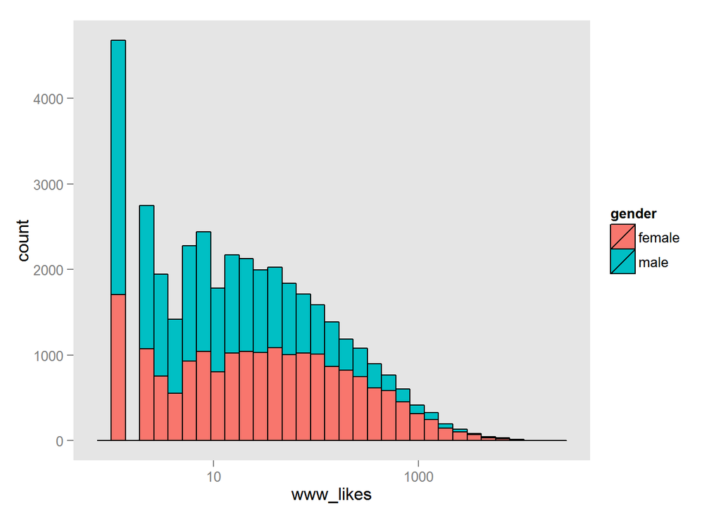

```r
qplot(x = www_likes, data = subset(pf, !is.na(gender)),
      color = I("black"), fill = gender) +
  scale_x_continuous(limits = c(0, 10), breaks = seq(0, 10, 1)) +
  scale_x_log10() +
  theme(plot.background = element_blank(),
   panel.grid.major = element_blank(),
   panel.grid.minor = element_blank(),
   panel.border = element_blank())
```

##### Exercise:

- find www_likes count for males

```r
pf_males = subset(pf, gender == "male")
sum(pf_males$www_likes)
```

```
## [1] 1430175
```

- find which gender has more www_likes

```r
pf_females = subset(pf, gender == "female")
sum(pf_females$www_likes)
```

```
## [1] 3507665
```

```r
##To subset for NA's in gender, use the following code
pf_na = subset(pf, is.na(gender))

## Count
sum(nrow(pf_females),nrow(pf_males),nrow(pf_na))
```

```
## [1] 99003
```

Solution: use `by()` function to calculate at once

```r
by(pf$www_likes, pf$gender, sum)
```

```
## pf$gender: female
## [1] 3507665
## --------------------------------------------------------
## pf$gender: male
## [1] 1430175
```

### Boxplot

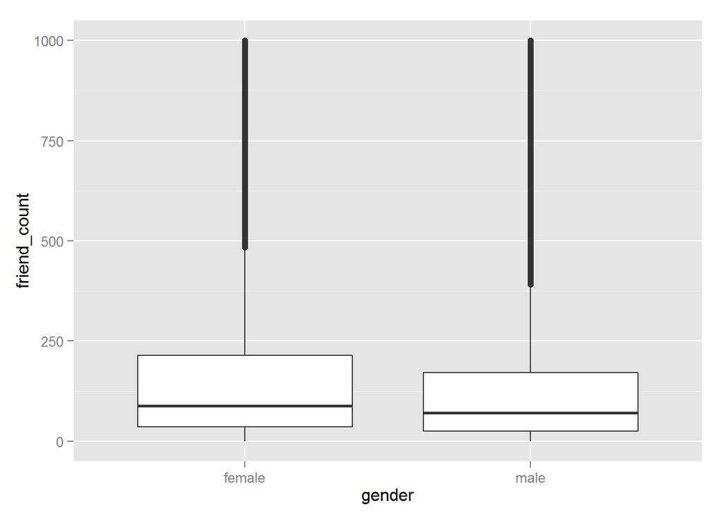

```r
qplot(x = gender, y = friend_count,
      data = subset(pf, !is.na(gender)),
      ylim = c(0,1000),
      geom = 'boxplot')
```

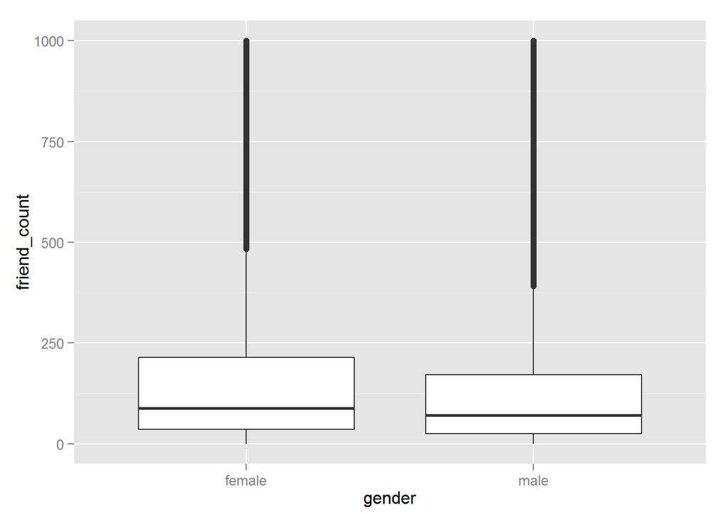

```r
qplot(x = gender, y = friend_count,
      data = subset(pf, !is.na(gender)),
      geom = 'boxplot') +
  scale_y_continuous(limits = c(0,1000))
```

A better way (without eliminating data points from the calculation), is to use the coord.cartesian() layer

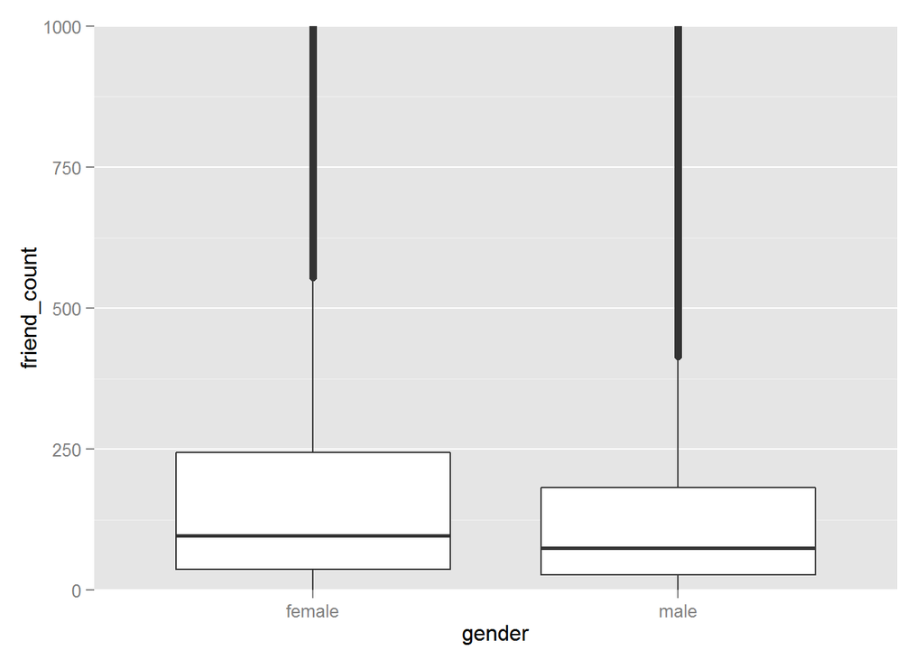

```r
qplot(x = gender, y = friend_count,
      data = subset(pf, !is.na(gender)),
      geom = 'boxplot') +
  coord_cartesian(ylim = c(0,1000))
```

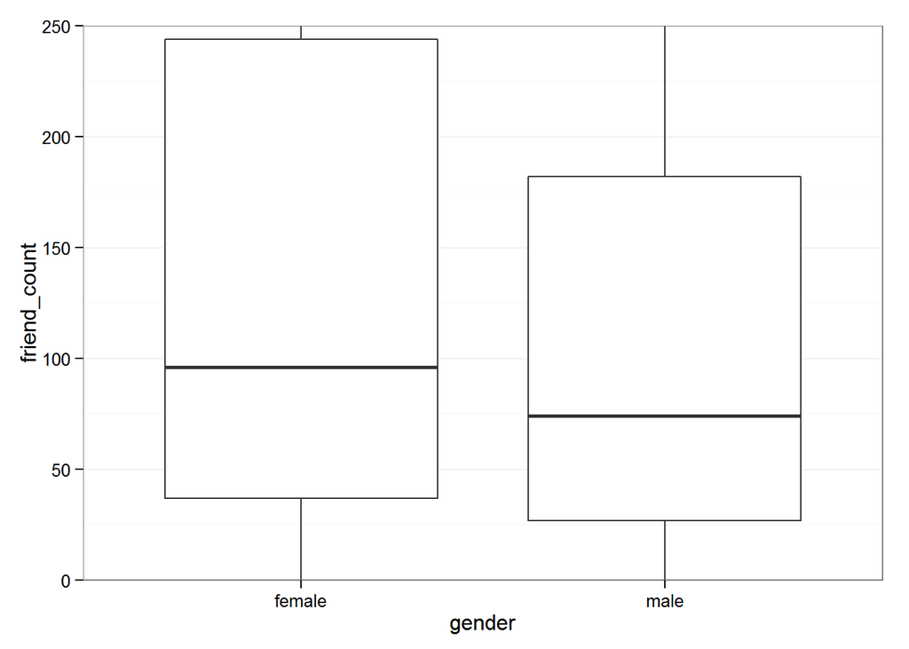

```r
qplot(x = gender, y = friend_count,
      data = subset(pf, !is.na(gender)),
      geom = 'boxplot') +
  coord_cartesian(ylim = c(0,250)) +
  theme_bw()
```

```r
###Use the by function to take a summary of the friend_count variable, spread out over gender
by(pf$friend_count, pf$gender, summary)
```

```
## pf$gender: female
##    Min. 1st Qu.  Median    Mean 3rd Qu.    Max.
##       0      37      96     242     244    4923
## --------------------------------------------------------
## pf$gender: male
##    Min. 1st Qu.  Median    Mean 3rd Qu.    Max.
##       0      27      74     165     182    4917
```

```r
## Answer the same question for friendship_initiated
by(pf$friendships_initiated, pf$gender, summary)
```

```
## pf$gender: female
##    Min. 1st Qu.  Median    Mean 3rd Qu.    Max.
##     0.0    19.0    49.0   113.9   124.8  3654.0
## --------------------------------------------------------
## pf$gender: male
##    Min. 1st Qu.  Median    Mean 3rd Qu.    Max.
##     0.0    15.0    44.0   103.1   111.0  4144.0
```

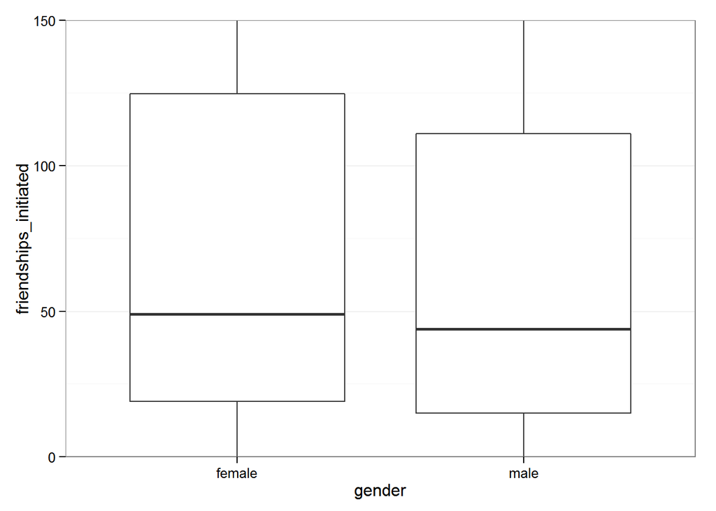

```r
## Boxplot
qplot(x = gender, y = friendships_initiated,
      data = subset(pf, !is.na(gender)),
      geom = 'boxplot') +
  coord_cartesian(ylim = c(0, 150)) +
  theme_bw()
```

### Covert a numeric variable in a boolean variable

May be needed with data that has a long tail. You may want to convert the values of the variable in binary boolean values to analyze whether a feature was used at all, rather than how many times the users used it. `mobile_likes` variable has a long tail

```r
summary(pf$mobile_likes)
```

```
##    Min. 1st Qu.  Median    Mean 3rd Qu.    Max.
##     0.0     0.0     4.0   106.1    46.0 25110.0
```

```r
##Logical count
summary(pf$mobile_likes > 0)
```

```
##    Mode   FALSE    TRUE    NA's
## logical   35056   63947       0
```

```
## stat_bin: binwidth defaulted to range/30. Use 'binwidth = x' to adjust this.
```

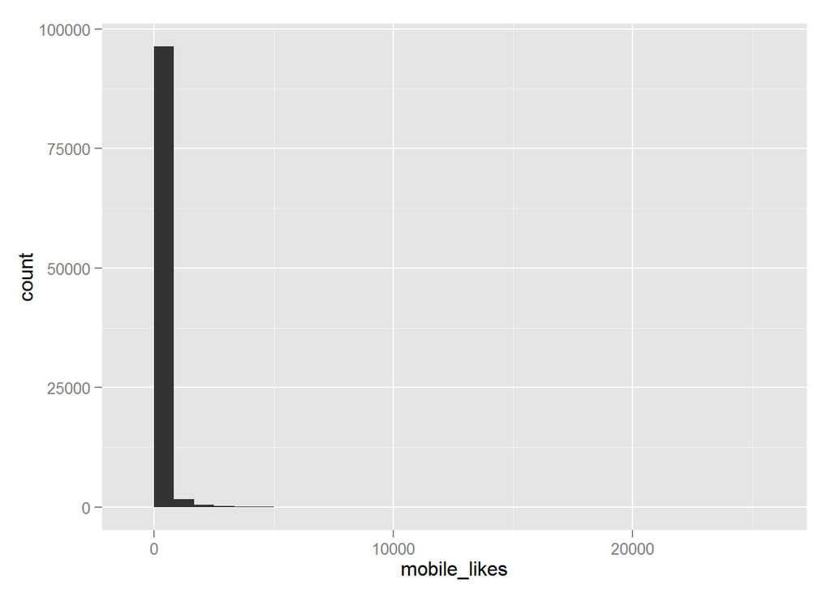

```r
##Basic qplot
qplot(x = mobile_likes, data = pf)
```

```
## stat_bin: binwidth defaulted to range/30. Use 'binwidth = x' to adjust this.
```

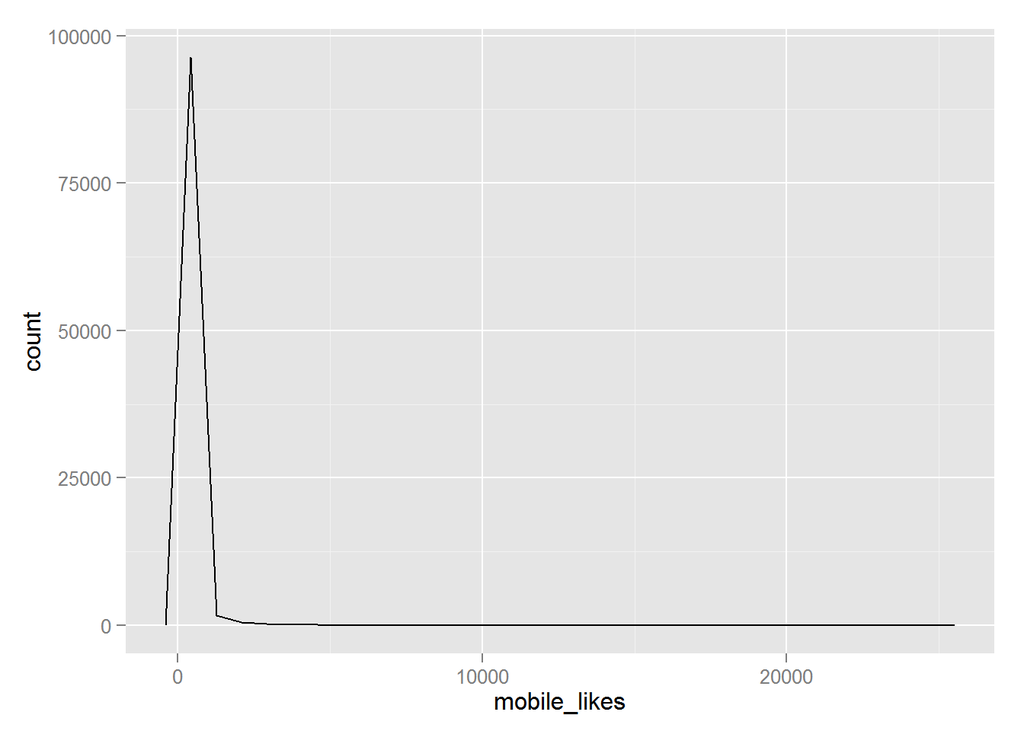

```r
##Histogram
qplot(x = mobile_likes, data = pf, geom = "freqpoly")
```

Convert the variable based on one condition (`ifelse()`)

```r
##Add a new column to the data frame with NA values in it
pf$mobile_check_in = NA

##Assign values 0 or 1 based on mobile_likes
pf$mobile_check_in = ifelse(pf$mobile_likes == 0, 0, 1)
summary(pf$mobile_check_in)
```

```
##    Min. 1st Qu.  Median    Mean 3rd Qu.    Max.
##  0.0000  0.0000  1.0000  0.6459  1.0000  1.0000
```

```r
##Factor the new variable
pf$mobile_check_in = factor(pf$mobile_check_in)
summary(pf$mobile_check_in)
```

```
##     0     1
## 35056 63947
```

```r
str(pf$mobile_check_in)
```

```
##  Factor w/ 2 levels "0","1": 1 1 1 1 1 1 1 1 1 1 ...
```

##### Exercise: percentage of users of mobile_like feature?

```r
mobile_users = subset(pf, pf$mobile_check_in == 1)
mobile_nonusers = subset(pf, pf$mobile_check_in == 0)

##Percentage of users on the total
nrow(mobile_users)/(nrow(mobile_users) + nrow(mobile_nonusers)) * 100
```

```
## [1] 64.59097
```

Solution:

```r
sum(pf$mobile_check_in == 1)/length(pf$mobile_check_in) * 100
```

```
## [1] 64.59097
```